# Survival

UNC EPID 722: Dr. Steve Cole

February 9, 2016

*NOTE: ALL SAS code below copied from 2016 EPID 722 lecture material. SAS code based on Steve Cole’s programs titled, “program5.25jan16.sas”. R code below is an adaptation to the SAS code written by Ann Von Holle.*

### 0.0.1 Preliminaries

#### 0.0.1.1 Specify packages for R

```r
#getwd() # use this to find relative directory for bib1.bib file above.

    #install.packages(c("knitr", "foreign", "tableone", "MCMCpack", "pspline")) # Note: you only need to do this once. then only if you want updates.
#  install.packages("data.table", "rms", "mgcv", "pspline") # Watch out, rms loads a lot of other packages. skipping for now.
  library(data.table)
  library(reshape2)
  library(survival)
  library(ggplot2)
#  library(rms)
  library(muhaz)
  library(pspline)
  library(mgcv)
  set.seed(123) # set seed so you get same results each time you run.
```

### 0.0.2 Read file and add in censor at 1/2 year to ease exposition

#### 0.0.2.1 SAS

```sas
libname mle "c:\temp";
%let dir = c:\temp;

* Read ASCII file;
data mle.b;
    infile "&dir\hividu15dec15.dat";
    input id 1-4 idu 6 white 8 age 10-11 cd4 13-16 drop 18 delta 20 @22 art 6.3 @29 t 6.3;
    if t>.5 then do; t=.5; delta=0; end;
run;

* Export to .csv for use in R;
proc export data=mle.b outfile="c:\temp\hividu15dec15.csv" dbms=csv replace; run;
```

#### 0.0.2.2 R

Read the data (created in the SAS program above).

```r
#getwd() # get the working directory
b = read.csv("c:/temp/hividu15dec15.csv", header=T) # read in data.
summary(b$delta)
```

```
##    Min. 1st Qu.  Median    Mean 3rd Qu.    Max.
## 0.00000 0.00000 0.00000 0.06271 0.00000 1.00000
```

```r
b = within(b, {
  delta = ifelse(t>0.5, 0, delta)
  t = ifelse(t>0.5, 0.5, t)
})
```

### 0.0.3 Time from 12/6/95 to AIDS or death in WIHS

#### 0.0.3.1 SAS

```sas
libname mle "c:\temp";
%let dir = c:\temp;
data a; set mle.b; run;

*Data;
proc means data=a n mean sum min max;
    var delta t;
    title "Time from 12/6/95 to AIDS or death in WIHS";
run;
```

```
## Time from 12/6/95 to AIDS or death in WIHS
##
## The MEANS Procedure
##
## Variable       N            Mean             Sum         Minimum         Maximum
## --------------------------------------------------------------------------------
## delta       1164       0.0627148      73.0000000               0       1.0000000
## t           1164       0.4833385     562.6060000       0.0030000       0.5000000
## --------------------------------------------------------------------------------
```

#### 0.0.3.2 R

```r
summary(b[,c("delta", "t")])
```

```
##      delta               t
##  Min.   :0.00000   Min.   :0.0030
##  1st Qu.:0.00000   1st Qu.:0.5000
##  Median :0.00000   Median :0.5000
##  Mean   :0.06271   Mean   :0.4833
##  3rd Qu.:0.00000   3rd Qu.:0.5000
##  Max.   :1.00000   Max.   :0.5000
```

### 0.0.4 Product limit survival curve

#### 0.0.4.1 SAS

```
##   t        n         r          s               se           se2
##
## 0.000    1164    0.000000    1.00000    .             .000000000
## 0.003    1164    0.001718    0.99828    .001212873    .001212872
## 0.011    1162    0.002577    0.99742    .001485033    .001485458
## 0.016    1161    0.004296    0.99570    .001915406    .001915238
## 0.019    1159    0.006014    0.99399    .002264325    .002264181
## 0.022    1157    0.007732    0.99227    .002565245    .002565116
## 0.033    1155    0.008591    0.99141    .002702939    .002703867
## 0.038    1154    0.009450    0.99055    .002833727    .002834609
## 0.052    1153    0.010309    0.98969    .002958525    .002959368
## 0.068    1152    0.011168    0.98883    .003078062    .003078869
## 0.074    1151    0.012027    0.98797    .003192928    .003193704
## 0.077    1150    0.012887    0.98711    .003303612    .003304359
## 0.079    1149    0.013746    0.98625    .003410519    .003411241
## 0.088    1148    0.014605    0.98540    .003513996    .003514693
## 0.090    1147    0.015464    0.98454    .003614335    .003615011
## 0.112    1146    0.016323    0.98368    .003711793    .003712449
## 0.120    1145    0.017182    0.98282    .003806590    .003807227
## 0.129    1144    0.018041    0.98196    .003898921    .003899540
## 0.131    1143    0.019759    0.98024    .004076689    .004075651
## 0.134    1141    0.020619    0.97938    .004162577    .004163304
## 0.164    1140    0.021478    0.97852    .004246579    .004247289
## 0.170    1139    0.022337    0.97766    .004328805    .004329498
## 0.172    1138    0.023196    0.97680    .004409354    .004410032
## 0.186    1137    0.024914    0.97509    .004565633    .004564415
## 0.189    1135    0.025773    0.97423    .004641665    .004642439
## 0.208    1134    0.026632    0.97337    .004716337    .004717096
## 0.227    1131    0.027493    0.97251    .004789977    .004794816
## 0.252    1129    0.028354    0.97165    .004862502    .004869345
## 0.255    1128    0.030077    0.96992    .005003887    .005008418
## 0.266    1126    0.030938    0.96906    .005072977    .005079625
## 0.282    1125    0.031800    0.96820    .005141015    .005147561
## 0.285    1124    0.034384    0.96562    .005338843    .005340718
## 0.307    1121    0.035245    0.96475    .005403062    .005409602
## 0.309    1120    0.036968    0.96303    .005528797    .005532809
## 0.320    1118    0.037830    0.96217    .005590492    .005596891
## 0.326    1116    0.039554    0.96045    .005711654    .005717887
## 0.339    1114    0.041278    0.95872    .005829860    .005835935
## 0.364    1111    0.042141    0.95786    .005888075    .005899262
## 0.372    1110    0.043004    0.95700    .005945613    .005956669
## 0.378    1109    0.043867    0.95613    .006002491    .006013421
## 0.383    1107    0.044731    0.95527    .006058836    .006072325
## 0.397    1106    0.046458    0.95354    .006169560    .006180068
## 0.400    1104    0.048186    0.95181    .006277921    .006288200
## 0.402    1102    0.049049    0.95095    .006331307    .006344299
## 0.408    1101    0.049913    0.95009    .006384145    .006397005
## 0.416    1100    0.051640    0.94836    .006488129    .006497881
## 0.422    1098    0.052504    0.94750    .006539406    .006551987
## 0.427    1097    0.053368    0.94663    .006590185    .006602645
## 0.444    1095    0.054232    0.94577    .006640577    .006655900
## 0.446    1094    0.055097    0.94490    .006690492    .006705670
## 0.457    1093    0.056826    0.94317    .006788835    .006800721
## 0.463    1091    0.057690    0.94231    .006837385    .006852248
## 0.476    1090    0.059419    0.94058    .006933086    .006944596
## 0.482    1088    0.061148    0.93885    .007027117    .007038419
## 0.485    1085    0.062014    0.93799    .007073667    .007091295
## 0.498    1083    0.062880    0.93712    .007119912    .007140633
```

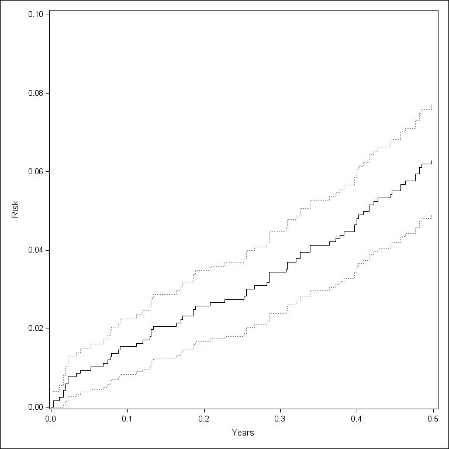

```sas
libname mle "c:\temp";
%let dir = c:\temp;
data a; set mle.b; run;


*Product limit survival curve data;
proc phreg data=a noprint;
    model t*delta(0)=;
    baseline out=b survival=s stderr=se/method=pl; *output survival function and se;
    output out=c(keep=t n) atrisk=n/method=pl; *output numbers in risk sets;
run;

proc sort data=c nodups; by t; *order times; run;

data c; set c; by t; if first.t; *keep distinct times; run;

data d; merge b c; by t; if t=0 then n=1164; if s>.; *merge keeping event times;
run;

data mle.d;
    set d;
    r=1-s;
    se2=s*sqrt((1-s)/n); *Peto se;
    if r>0 then do;
        lo=max(0,r-1.96*se);
        hi=min(1,r+1.96*se);
    end;
    label s="Survival" r="Risk" t="Years";
run;

proc print data=mle.d noobs;
    var t n r s se se2;
run;

*Plot;
*ods listing gpath="Y:\\Cole\\Teaching\\EPID722\2016\\";
ods listing gpath="c:\\temp";
ods graphics/reset imagename="Survival" imagefmt=jpeg height=8in width=8in;
proc sgplot data=mle.d noautolegend;
    yaxis values=(0 to .1 by .02);
    xaxis values=(0 to .5 by .1);
    step x=t y=r/lineattrs=(color=black);
    step x=t y=lo/lineattrs=(color=black pattern=dot);
    step x=t y=hi/lineattrs=(color=black pattern=dot);
    run; quit;
```

#### 0.0.4.2 R

```r
s.1 = survfit(Surv(t, delta) ~ 1, data=b)

sum.surv = summary(s.1)
names(sum.surv)
```

```
##  [1] "n"         "time"      "n.risk"    "n.event"   "n.censor"
##  [6] "surv"      "type"      "std.err"   "upper"     "lower"
## [11] "conf.type" "conf.int"  "call"      "table"
```

```r
d = data.frame(
  t = sum.surv$time,
  n = sum.surv$n.risk,
  r = 1-sum.surv$surv,
  s = sum.surv$surv,
  n.event = sum.surv$n.event,
  n.censor = sum.surv$n.censor,
  se = sum.surv$std.err,
  se2 = sum.surv$surv*sqrt((1-sum.surv$surv)/sum.surv$n.risk) # Peto se
)

head(d)
```

```
##       t    n           r         s n.event n.censor          se
## 1 0.003 1164 0.001718213 0.9982818       2        0 0.001213916
## 2 0.011 1162 0.002577320 0.9974227       1        0 0.001486097
## 3 0.016 1161 0.004295533 0.9957045       2        0 0.001916890
## 4 0.019 1159 0.006013746 0.9939863       2        0 0.002266137
## 5 0.022 1157 0.007731959 0.9922680       2        0 0.002567336
## 6 0.033 1155 0.008591065 0.9914089       1        0 0.002705038
##           se2
## 1 0.001212873
## 2 0.001485458
## 3 0.001915238
## 4 0.002264181
## 5 0.002565116
## 6 0.002703867
```

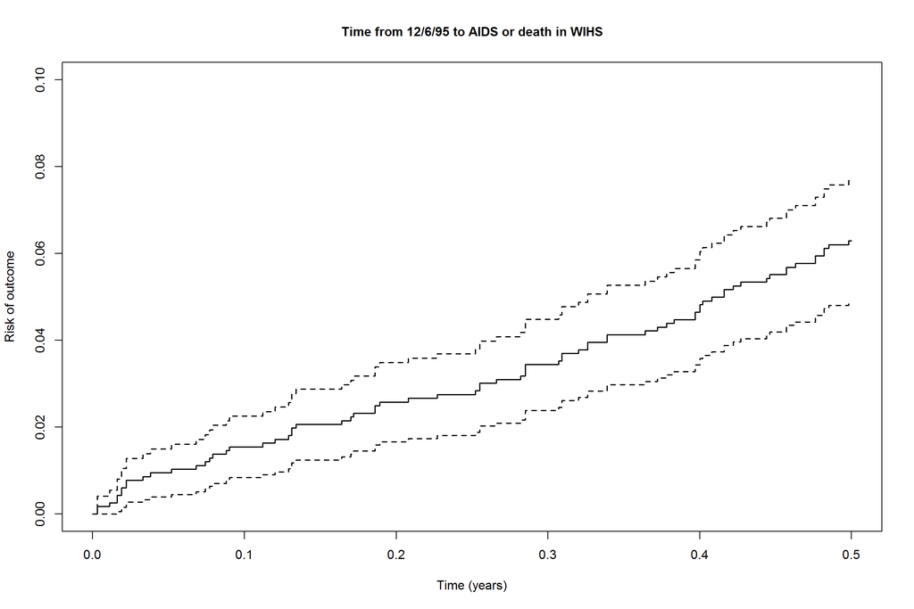

```r
plot(s.1, lwd=1.5,
     fun = function(y) 1-y ,
     xlab="Time (years)",
     ylab="Risk of outcome",
     ylim=c(0,0.1),
     xlim=c(0,0.5),
     main="Time from 12/6/95 to AIDS or death in WIHS",
     cex.lab=1, cex.axis=1, cex.main=1, cex.sub=1.5,
     mark.time=F)
```

#### 0.0.4.3 R, extract out strata information from survival estimates

```r
# way to extract out strata (of IDU variable)

s.strata = survfit(Surv(t, delta) ~ 1 + strata(idu), data=b)

sum.surv.strata = summary(s.strata)
names(sum.surv.strata)
```

```
##  [1] "n"         "time"      "n.risk"    "n.event"   "n.censor"
##  [6] "surv"      "type"      "strata"    "std.err"   "upper"
## [11] "lower"     "conf.type" "conf.int"  "call"      "table"
```

```r
sum.surv$strata
```

```r
d.strata = data.frame(
  strata = sum.surv.strata$strata,
  t = sum.surv.strata$time,
  n = sum.surv.strata$n.risk,
  r = 1-sum.surv.strata$surv,
  s = sum.surv.strata$surv,
  n.event = sum.surv.strata$n.event,
  n.censor = sum.surv.strata$n.censor,
  se = sum.surv.strata$std.err,
  se2 = sum.surv.strata$surv*sqrt((1-sum.surv.strata$surv)/sum.surv.strata$n.risk) # Peto se
)

head(d.strata)
```

```
##              strata     t   n           r         s n.event n.censor
## 1 strata(idu)=idu=0 0.003 725 0.001379310 0.9986207       1        0
## 2 strata(idu)=idu=0 0.011 724 0.002758621 0.9972414       1        0
## 3 strata(idu)=idu=0 0.016 723 0.004137931 0.9958621       1        0
## 4 strata(idu)=idu=0 0.019 722 0.005517241 0.9944828       1        0
## 5 strata(idu)=idu=0 0.074 721 0.006896552 0.9931034       1        0
## 6 strata(idu)=idu=0 0.079 720 0.008275862 0.9917241       1        0
##            se         se2
## 1 0.001378359 0.001377408
## 2 0.001947947 0.001946601
## 3 0.002384088 0.002382438
## 4 0.002751000 0.002749094
## 5 0.003073578 0.003071446
## 6 0.003364597 0.003362260
```

### 0.0.5 Hazard

See Appendix A, p2430, of assigned reading (1) for estimate of hazard, $h(t)$,

First, the Kaplan-Meier estimator for the survival function, $S(t)$:

$S^{KM}(t) = \displaystyle\prod_{k:R_k \leq t} \frac{1-Y_k}{N_k}$,

where “the product is taken over all ordered events up to time t”.

- $Y_k$ is the number of individuals who died at each of the ranked times $R_k$.
- $N_k$ is the number of individuals at-risk for mortality while under observation at distinct ranked event time $R_k$ for $k = 1, \ldots, D^{\prime}$.

$h_k = \frac{Y_k}{N_k \Delta_k}$

where $\Delta_k = R_k - R_{k-1}$ and $R_0=0$ and $R_k$ is observed event time at rank $k$.

The cumulative hazard, $H(t)$ is estimated as $H^{KM}_t = -log(S^{KM}(t))$.

#### 0.0.5.1 SAS

```sas
libname mle "c:\temp";
%let dir = c:\temp;
data d; set mle.d; run;

*Some other pieces;
proc sort data=d;
    by descending s;
data mle.d;
    set d;
    by descending s;
    retain chm1 0 sm1 1 tm1 0;
    if t=0 then do; d=0; *n=315; end;
    deltat=t-tm1;
    if s>0 then ch=-log(s);
    y=round((ch-chm1)*n,1);
    *above recreates y because SAS does not output;
    if deltat>0 then h=y/(n*deltat);
    label n=;
    logh=log(h);
    output;
    chm1=ch; sm1=s; tm1=t;
    drop chm1 sm1 tm1;
run;

proc print data=mle.d noobs;
    title2 "Hazard function";
    var t y n deltat h;
run;
```

```
## Hazard function
##
##   t      y      n     deltat       h
##
## 0.000    0    1164     0.000     .
## 0.003    2    1164     0.003    0.57274
## 0.011    1    1162     0.008    0.10757
## 0.016    2    1161     0.005    0.34453
## 0.019    2    1159     0.003    0.57521
## 0.022    2    1157     0.003    0.57620
## 0.033    1    1155     0.011    0.07871
## 0.038    1    1154     0.005    0.17331
## 0.052    1    1153     0.014    0.06195
## 0.068    1    1152     0.016    0.05425
## 0.074    1    1151     0.006    0.14480
## 0.077    1    1150     0.003    0.28986
## 0.079    1    1149     0.002    0.43516
## 0.088    1    1148     0.009    0.09679
## 0.090    1    1147     0.002    0.43592
## 0.112    1    1146     0.022    0.03966
## 0.120    1    1145     0.008    0.10917
## 0.129    1    1144     0.009    0.09713
## 0.131    2    1143     0.002    0.87489
## 0.134    1    1141     0.003    0.29214
## 0.164    1    1140     0.030    0.02924
## 0.170    1    1139     0.006    0.14633
## 0.172    1    1138     0.002    0.43937
## 0.186    2    1137     0.014    0.12564
## 0.189    1    1135     0.003    0.29369
## 0.208    1    1134     0.019    0.04641
## 0.227    1    1131     0.019    0.04654
## 0.252    1    1129     0.025    0.03543
## 0.255    2    1128     0.003    0.59102
## 0.266    1    1126     0.011    0.08074
## 0.282    1    1125     0.016    0.05556
## 0.285    3    1124     0.003    0.88968
## 0.307    1    1121     0.022    0.04055
## 0.309    2    1120     0.002    0.89286
## 0.320    1    1118     0.011    0.08131
## 0.326    2    1116     0.006    0.29869
## 0.339    2    1114     0.013    0.13810
## 0.364    1    1111     0.025    0.03600
## 0.372    1    1110     0.008    0.11261
## 0.378    1    1109     0.006    0.15029
## 0.383    1    1107     0.005    0.18067
## 0.397    2    1106     0.014    0.12917
## 0.400    2    1104     0.003    0.60386
## 0.402    1    1102     0.002    0.45372
## 0.408    1    1101     0.006    0.15138
## 0.416    2    1100     0.008    0.22727
## 0.422    1    1098     0.006    0.15179
## 0.427    1    1097     0.005    0.18232
## 0.444    1    1095     0.017    0.05372
## 0.446    1    1094     0.002    0.45704
## 0.457    2    1093     0.011    0.16635
## 0.463    1    1091     0.006    0.15277
## 0.476    2    1090     0.013    0.14114
## 0.482    2    1088     0.006    0.30637
## 0.485    1    1085     0.003    0.30722
## 0.498    1    1083     0.013    0.07103
```

For variance of the cumulative hazard function, $H(t)$, see Appendix B section at top of second column, page 2430, of assigned reading (1).

According to Appendix A (p 2430),

Variance for cumulative hazard:

$V\left(H^{KM}(t)\right) = \displaystyle\sum_{k:R_k \leq t} \frac{Y_k}{N_k (N_k - Y_k)}$

Variance for survival function, $S^{KM}(t)$:

$V\left(S^{KM}(t)\right) = S^{KM}(t)^2 \times \displaystyle\sum_{(k:R_k \leq t)} \frac{Y_k}{N_k(N_k-Y_k)}$

```sas
libname mle "c:\temp";
%let dir = c:\temp;
data d; set mle.d; run;

data d;
    set mle.d;
    by descending s;
    retain v 0;
    v=v+y/(n*(n-y));
    se3=sqrt(s**2*v); *se by hand;
    ch=-log(s);
    output;
run;

proc print data=d noobs;
    title2 "Standard error by hand";
    var t ch s se se3;
run;
```

```
## Standard error by hand
##
##   t         ch          s               se           se3
##
## 0.000    0.000000    1.00000    .             .000000000
## 0.003    0.001720    0.99828    .001212873    .001213916
## 0.011    0.002581    0.99742    .001485033    .001486097
## 0.016    0.004305    0.99570    .001915406    .001916890
## 0.019    0.006032    0.99399    .002264325    .002266137
## 0.022    0.007762    0.99227    .002565245    .002567336
## 0.033    0.008628    0.99141    .002702939    .002705038
## 0.038    0.009495    0.99055    .002833727    .002835839
## 0.052    0.010363    0.98969    .002958525    .002960652
## 0.068    0.011231    0.98883    .003078062    .003080207
## 0.074    0.012100    0.98797    .003192928    .003195093
## 0.077    0.012970    0.98711    .003303612    .003305797
## 0.079    0.013841    0.98625    .003410519    .003412726
## 0.088    0.014713    0.98540    .003513996    .003516225
## 0.090    0.015585    0.98454    .003614335    .003616588
## 0.112    0.016458    0.98368    .003711793    .003714070
## 0.120    0.017331    0.98282    .003806590    .003808891
## 0.129    0.018206    0.98196    .003898921    .003901246
## 0.131    0.019957    0.98024    .004076689    .004079221
## 0.134    0.020834    0.97938    .004162577    .004165130
## 0.164    0.021712    0.97852    .004246579    .004249153
## 0.170    0.022590    0.97766    .004328805    .004331400
## 0.172    0.023469    0.97680    .004409354    .004411971
## 0.186    0.025230    0.97509    .004565633    .004568435
## 0.189    0.026111    0.97423    .004641665    .004644486
## 0.208    0.026993    0.97337    .004716337    .004719178
## 0.227    0.027878    0.97251    .004789977    .004792838
## 0.252    0.028764    0.97165    .004862502    .004865383
## 0.255    0.030539    0.96992    .005003887    .005006938
## 0.266    0.031427    0.96906    .005072977    .005076047
## 0.282    0.032316    0.96820    .005141015    .005144103
## 0.285    0.034989    0.96562    .005338843    .005342355
## 0.307    0.035882    0.96475    .005403062    .005406587
## 0.309    0.037669    0.96303    .005528797    .005532469
## 0.320    0.038564    0.96217    .005590492    .005594176
## 0.326    0.040357    0.96045    .005711654    .005715480
## 0.339    0.042154    0.95872    .005829860    .005833823
## 0.364    0.043055    0.95786    .005888075    .005892049
## 0.372    0.043956    0.95700    .005945613    .005949597
## 0.378    0.044858    0.95613    .006002491    .006006487
## 0.383    0.045762    0.95527    .006058836    .006062843
## 0.397    0.047572    0.95354    .006169560    .006173699
## 0.400    0.049385    0.95181    .006277921    .006282188
## 0.402    0.050293    0.95095    .006331307    .006335584
## 0.408    0.051202    0.95009    .006384145    .006388432
## 0.416    0.053022    0.94836    .006488129    .006492541
## 0.422    0.053933    0.94750    .006539406    .006543827
## 0.427    0.054845    0.94663    .006590185    .006594616
## 0.444    0.055758    0.94577    .006640577    .006645017
## 0.446    0.056673    0.94490    .006690492    .006694942
## 0.457    0.058504    0.94317    .006788835    .006793406
## 0.463    0.059421    0.94231    .006837385    .006841965
## 0.476    0.061258    0.94058    .006933086    .006937784
## 0.482    0.063098    0.93885    .007027117    .007031930
## 0.485    0.064020    0.93799    .007073667    .007078487
## 0.498    0.064944    0.93712    .007119912    .007124741
```

#### 0.0.5.2 R

```r
d.rev = rbind(c(t=0, n=d$n[1], r=NA, s=NA, n.event=0, n.censor=NA, se=NA, se2=NA),
              d) # add a time origin point here.

d.rev$delta.t = c(0,diff(as.matrix(d.rev$t))) # get delta t
d.rev$h = with(d.rev, n.event / (n*delta.t))

some.vars = c("t", "n.event", "n", "delta.t", "h")
head(d.rev[,some.vars]) # check with SAS numbers
```

```
##       t n.event    n delta.t         h
## 1 0.000       0 1164   0.000       NaN
## 2 0.003       2 1164   0.003 0.5727377
## 3 0.011       1 1162   0.008 0.1075731
## 4 0.016       2 1161   0.005 0.3445306
## 5 0.019       2 1159   0.003 0.5752085
## 6 0.022       2 1157   0.003 0.5762028
```

Standard error by hand

```r
d.rev = within(d.rev, {
  sum.1 = with(d.rev, n.event / (n*(n-n.event)))
  v = with(d.rev, cumsum(sum.1))
  se3 = with(d.rev, sqrt(s^2*v))
  ch = -log(s)
})

head(d.rev[,c("t", "ch", "s", "se", "se3")])
```

```
##       t          ch         s          se         se3
## 1 0.000          NA        NA          NA          NA
## 2 0.003 0.001719691 0.9982818 0.001213916 0.001213916
## 3 0.011 0.002580647 0.9974227 0.001486097 0.001486097
## 4 0.016 0.004304785 0.9957045 0.001916890 0.001916890
## 5 0.019 0.006031901 0.9939863 0.002266137 0.002266137
## 6 0.022 0.007762005 0.9922680 0.002567336 0.002567336
```

### 0.0.6 Plots

#### 0.0.6.1 SAS

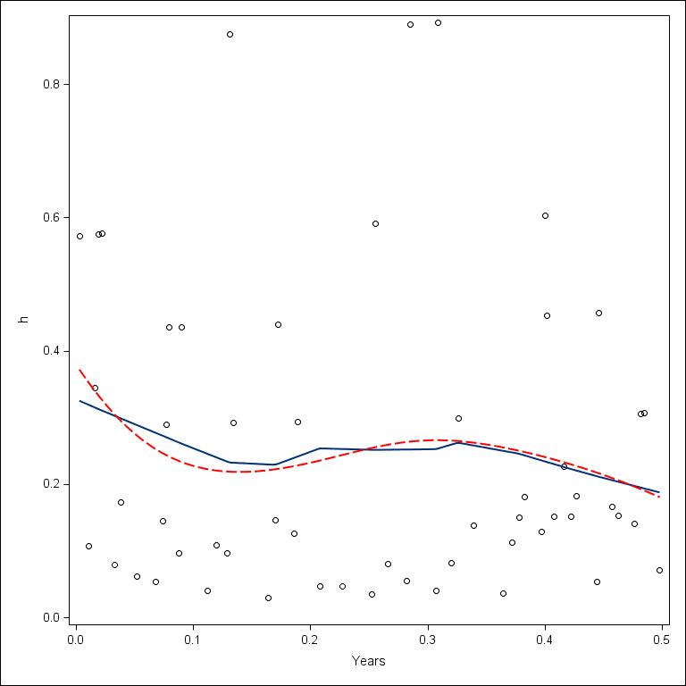

```sas
libname mle "c:\temp";
%let dir = c:\temp;

*ods listing gpath="Y:\\Cole\\Teaching\\EPID722\\2016\\";
ods listing gpath="c:\\temp";
ods graphics/reset imagename="Hazard" imagefmt=jpeg height=8in width=8in;
proc sgplot data=mle.d noautolegend;
    xaxis values=(0 to .5 by .1);
    loess x=t y=h/smooth=.6;
    pbspline x=t y=h/lineattrs=(color=red) nomarkers;
run; quit;
```

#### 0.0.6.2 R

Plot hazards using muhaz function

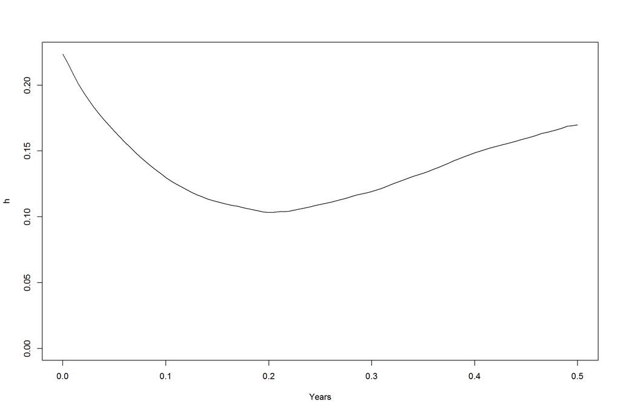

```r
fmuhaz = muhaz(b$t, b$delta,
              max.time=0.5,
              bw.method="g")
plot(fmuhaz, xlab="Years", ylab="h")
```

```r
# see arxiv.org/pdf/1509.03253 and http://bit.ly/1SGaqjV
#haz.dat = data.frame(t=fmuhaz$est.grid, h=fmuhaz$haz.est) # extract out hazard estimates from muhaz object to data frame
```

Plot of hazards from manually calculated hazards

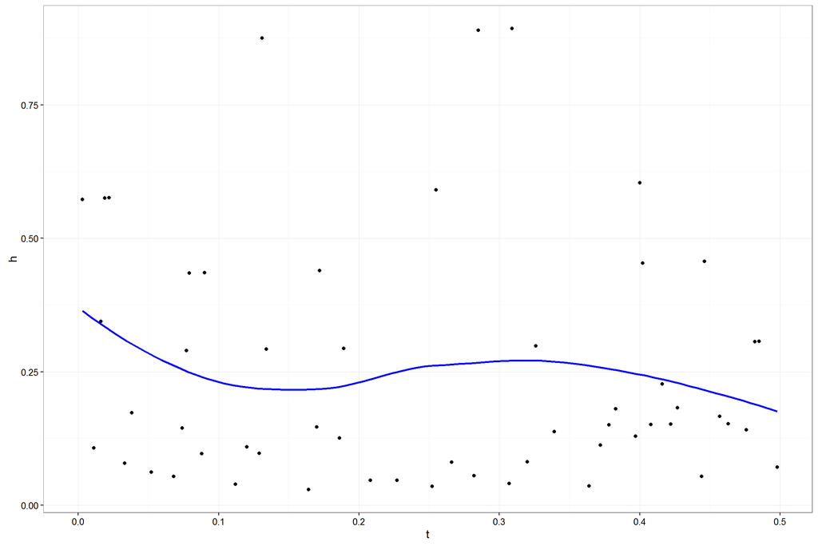

```r
p.haz = ggplot(data = d.rev, aes(x=t, y=h)) +
  geom_point() +
  stat_smooth(method="loess", colour="blue", se=F) +
#  stat_smooth(method = 'gam', colour = 'red', se = F, formula = y ~ s(x, bs='ps')) #note: this part not working for some reason, see http://bit.ly/1W2MO8B
  theme_bw()

p.haz
```

Assigned reading

1. Cole SR, Hudgens MG. Survival analysis in infectious disease research: Describing events in time: *AIDS* [electronic article]. 2010;24(16):2423–2431. (http://content.wkhealth.com/linkback/openurl?sid=WKPTLP:landingpage&an=00002030-201010230-00001)